# PCA And Sequence Alignment

Abdullah Taman

2024-03-09

```r
library(tidyverse)
library(rentrez)
library(seqinr)
library(Biostrings)
```

```r
library(ggplot2)
library("FactoMineR")
library(ggcorrplot)
library('corrr')
```

## # Part One

First performing the PCA

```r
cancer <- read.csv("J:/champions work/datasets/BrainCancerMin.csv", header = TRUE)
?princomp()
```

```
## starting httpd help server ... done
```

Now we’ll perform the PCA I faced an issue with the code, This error: Error in princomp.default(remove_type, cor = TRUE, scores = TRUE) : ‘princomp’ can only be used with more units than variables

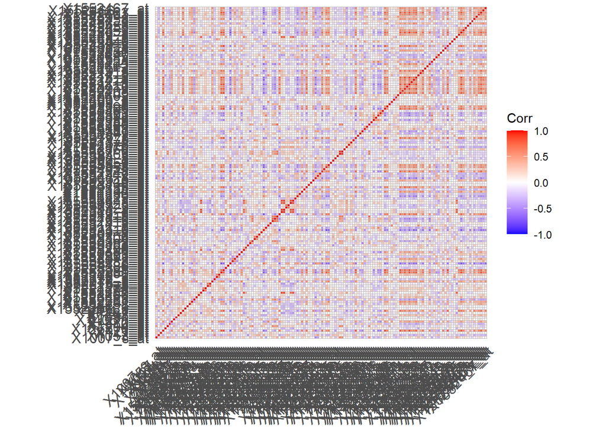

```r
remove_type <- subset(cancer, select = c(3:ncol(cancer)))
data_normalized <- scale(remove_type)
corr_matrix <- cor(data_normalized)
ggcorrplot(corr_matrix)
```

```r
data.pca <- princomp(as.data.frame(corr_matrix))
#summary(data.pca)
```

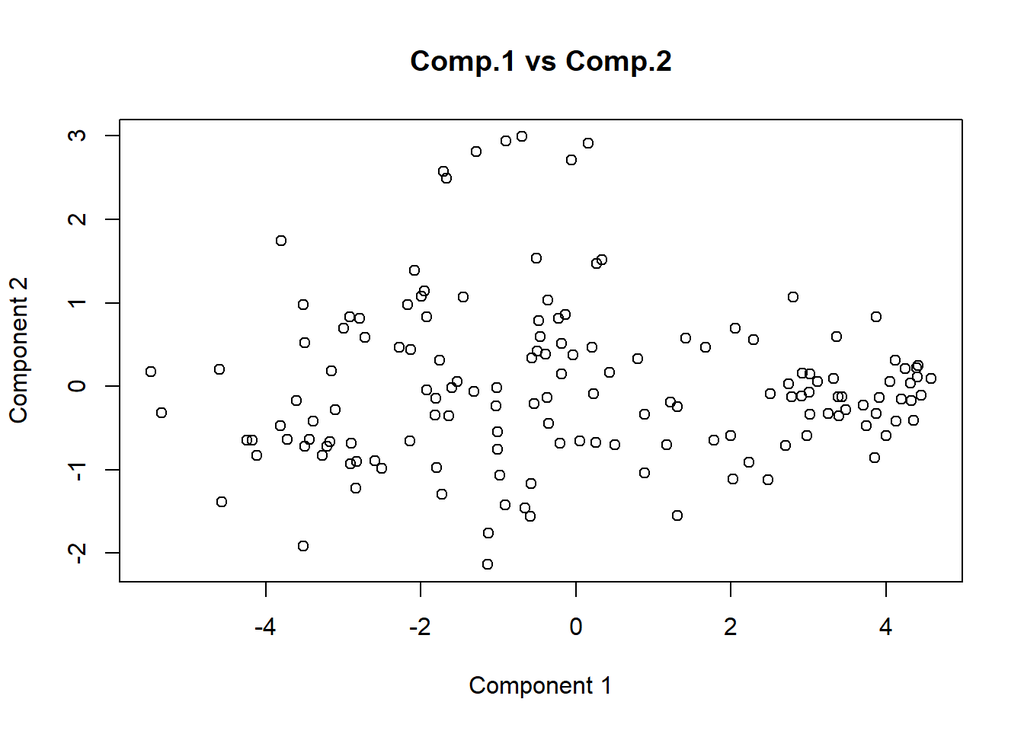

```r
# Extract principal component scores
pc_scores <- data.pca$scores

# Plot Comp.1 vs Comp.2
plot(pc_scores[,1], pc_scores[,2], xlab = "Component 1", ylab = "Component 2",
     main = "Comp.1 vs Comp.2")
```

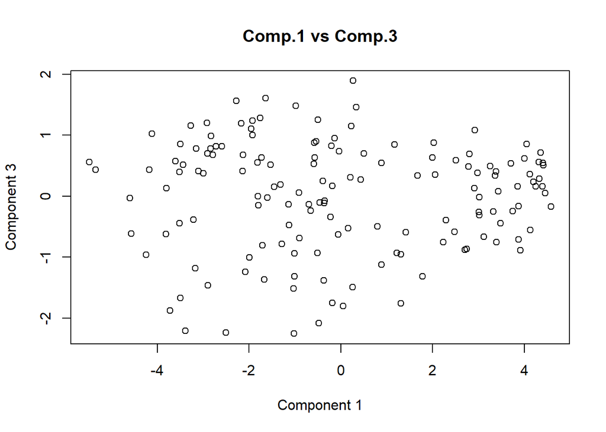

```r
# Plot Comp.1 vs Comp.3
plot(pc_scores[,1], pc_scores[,3], xlab = "Component 1", ylab = "Component 3",
     main = "Comp.1 vs Comp.3")
```

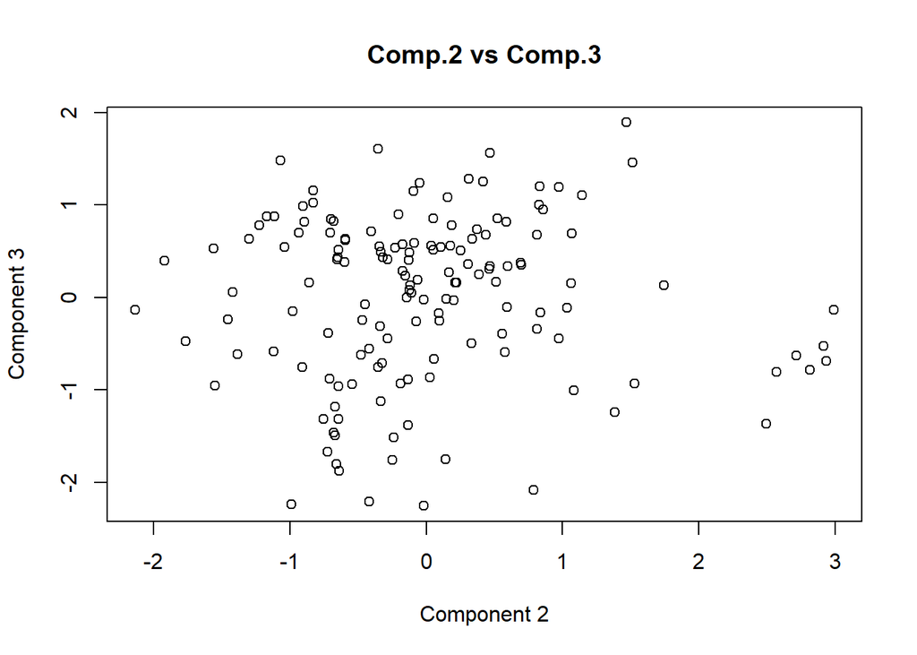

```r
# Plot Comp.2 vs Comp.3
plot(pc_scores[,2], pc_scores[,3], xlab = "Component 2", ylab = "Component 3",
     main = "Comp.2 vs Comp.3")
```

Component 1 vs Component 2 is the best, why ? You could see that the number of points that are overlapped is the least number in it.

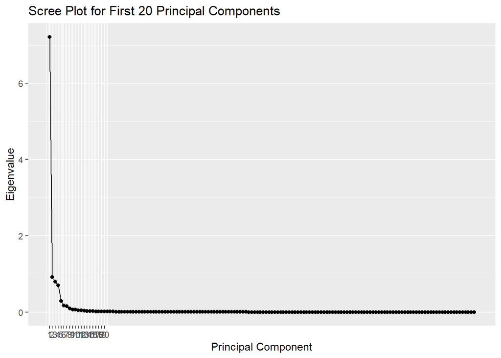

```r
# Extract eigenvalues
eigenvalues <- data.pca$sdev^2

# Create data frame for plotting
scree_data <- data.frame(Component = 1:length(eigenvalues), Eigenvalue = eigenvalues)

# Plot scree plot
ggplot(scree_data, aes(x = Component, y = Eigenvalue)) +
  geom_point() +
  geom_line() +
  scale_x_continuous(breaks = seq(1, 20, by = 1)) +  # Adjust x-axis breaks for better readability
  labs(x = "Principal Component", y = "Eigenvalue", title = "Scree Plot for First 20 Principal Components")
```

In multivariate statistics, a scree plot is a line plot of the eigenvalues of factors or principal components in an analysis.[1] The scree plot is used to determine the number of factors to retain in an exploratory factor analysis (FA) or principal components to keep in a principal component analysis (PCA). We could see that starting from the 6th eigen value the eigen values are so small that they don’t affect anything in the results.

## # Part Two

```r
diab <- read.csv("J:/champions work/datasets/diabetes_prediction_dataset.csv")
```

```r
allele1 <- substr(diab$alleles, 1, 1)  # First character of alleles
allele2 <- substr(diab$alleles, 2, 2)  # Second character of alleles

allele_counts <- table(No_Diabetes = c(allele1, allele2), Diabetes = rep(diab$diabetes, 2))

# Convert table to data frame for easier manipulation
allele_counts_df <- as.data.frame(allele_counts)

# Print the resulting table
print(allele_counts_df)
```

```
##   No_Diabetes Diabetes  Freq
## 1           A        0 91660
## 2           C        0 91340
## 3           A        1  8499
## 4           C        1  8501
```

```r
allele_counts <- matrix(c(91660, 8499, 91340, 8501), ncol = 2, byrow = TRUE)

# Perform Fisher's exact test
fisher_result <- fisher.test(allele_counts)

# Extract p-value
p_value <- fisher_result$p.value

# Report the p-value
print(p_value)
```

```
## [1] 0.816139
```

It’s not significant at all, .81 is very big. Which means that the association is not significant.

```r
# Extract BMI samples for each allele family
BMI_AA <- subset(diab, alleles == "AA")$bmi
BMI_AC <- subset(diab, alleles == "AC")$bmi
BMI_CC <- subset(diab, alleles == "CC")$bmi

# Perform t-test between BMI samples for AA and AC allele families
t_test_AA_AC <- t.test(BMI_AA, BMI_AC)

# Perform t-test between BMI samples for AA and CC allele families
t_test_AA_CC <- t.test(BMI_AA, BMI_CC)

# Perform t-test between BMI samples for AC and CC allele families
t_test_AC_CC <- t.test(BMI_AC, BMI_CC)

# Report p-values
p_value_AA_AC <- t_test_AA_AC$p.value
p_value_AA_CC <- t_test_AA_CC$p.value
p_value_AC_CC <- t_test_AC_CC$p.value

# Print p-values
print(p_value_AA_AC)
```

```
## [1] 0.5125191
```

```r
print(p_value_AA_CC)
```

```
## [1] 0.8228364
```

```r
print(p_value_AC_CC)
```

```
## [1] 0.6691533
```

It’s clear that there is no real significant difference between the family of alleles when it’s related to BMI phenotype.

## # Part Three

There are two mismatches.

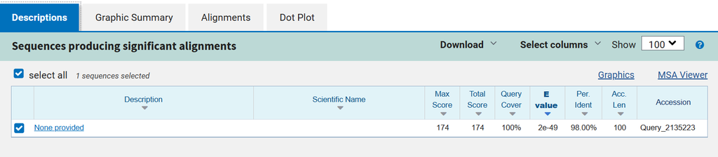

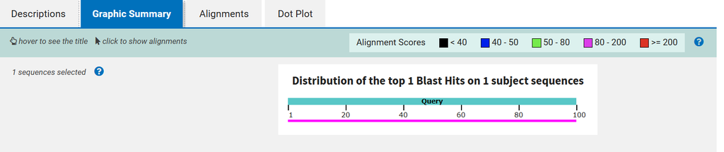

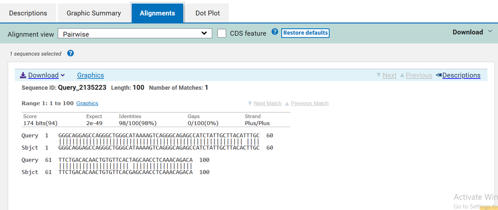

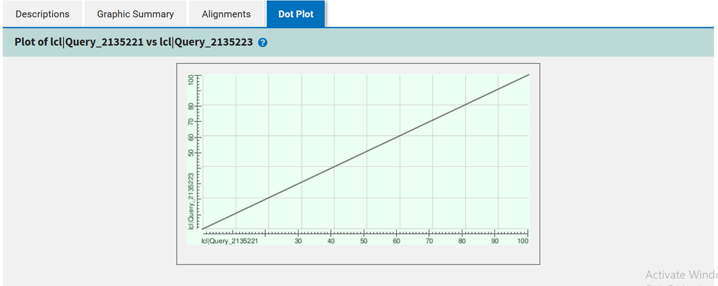

```r
seq1 <- entrez_fetch(db = "nucleotide", id = "NG_050578.1", rettype = "fasta")
seq2 <- entrez_fetch(db = "nucleotide", id = "X03562.1", rettype = "fasta")
seq1
```

```
## [1] ">NG_050578.1 Homo sapiens INS-IGF2 readthrough (INS-IGF2), RefSeqGene on chromosome 11\nGAGGTGCGGATCCTGGGCGGCCAGGGAAGGTCTCTGCCGCCAGGGAAGTGTCCCAGAGACCCCTGGAGGG\nGCTGCTGACACCCCCGGTGCCCCCACCTCGAGCATGACCCAGGGCTGCCTCTCCCCATCCTTCATCCTCC\nCTGCTCCACAGGACATTGGCCTGGCGTCCCTGGGGGCCTCGGATGAGGAAATTGAGAAGC…
```

```r
seq1_lines <- unlist(strsplit(seq1, "\n"))
seq1_lines <- seq1_lines[!grepl(">", seq1_lines)]
seq1_clean <- paste(seq1_lines, collapse = "")

seq2_lines <- unlist(strsplit(seq2, "\n"))
seq2_lines <- seq2_lines[!grepl(">", seq2_lines)]
seq2_clean <- paste(seq2_lines, collapse = "")

seq1 <- DNAStringSet(seq1_clean)
seq2 <- DNAStringSet(seq2_clean)

print(seq1)
```

```
## DNAStringSet object of length 1:
##     width seq
## [1] 39098 GAGGTGCGGATCCTGGGCGGCCAGGGAAGGTCTC...CCATCCCTCCACTCATCCATCCACTCATCCCTC
```

```r
print(seq2)
```

```
## DNAStringSet object of length 1:
##     width seq
## [1]  8837 CCCAACCCCGCGCACAGCGGGCACTGGTTTCGGG...TCTCCCTTCTCACGGGAATTTTCAGGGTAAACT
```

```r
freq_seq1 <- alphabetFrequency(seq1)
freq_seq2 <- alphabetFrequency(seq2)
print(freq_seq1)
```

```
##         A     C     G    T M R W S Y K V H D B N - + .
## [1,] 7355 12386 11660 7697 0 0 0 0 0 0 0 0 0 0 0 0 0 0
```

```r
print(freq_seq2)
```

```
##         A    C    G    T M R W S Y K V H D B  N - + .
## [1,] 1388 3037 2697 1685 0 0 0 0 0 0 0 0 0 0 30 0 0 0
```

```r
seq1_has_gaps_ambiguous <- any(names(freq_seq1) %in% c("-", "N"))
seq2_has_gaps_ambiguous <- any(names(freq_seq2) %in% c("-", "N"))
print(seq1_has_gaps_ambiguous)
```

```
## [1] FALSE
```

```r
print(seq2_has_gaps_ambiguous)
```

```
## [1] FALSE
```

```r
seq1_has_gaps_ambiguous <- any(grepl("[-N]", seq1))
seq2_has_gaps_ambiguous <- any(grepl("[-N]", seq2))

# 2. Remove gaps and ambiguous bases from sequences
seq1_cleaned <- gsub("[-N]", "", seq1)
seq2_cleaned <- gsub("[-N]", "", seq2)
seq1_length_before <- nchar(seq1)
seq2_length_before <- nchar(seq2)
seq1_length_after <- nchar(seq1_cleaned)
seq2_length_after <- nchar(seq2_cleaned)
print(paste("Sequence 1 length before cleaning:", seq1_length_before))
```

```
## [1] "Sequence 1 length before cleaning: 39098"
```

```r
print(paste("Sequence 2 length before cleaning:", seq2_length_before))
```

```
## [1] "Sequence 2 length before cleaning: 8837"
```

```r
print(paste("Sequence 1 length after cleaning:", seq1_length_after))
```

```
## [1] "Sequence 1 length after cleaning: 39098"
```

```r
print(paste("Sequence 2 length after cleaning:", seq2_length_after))
```

```
## [1] "Sequence 2 length after cleaning: 8807"
```

```r
run_pairwise_alignment <- function(seq1, seq2) {
  # Run Pairwise Local Alignment
  alignment <- pairwiseAlignment(seq1, seq2, substitutionMatrix = "BLOSUM62", gapOpening = -10, gapExtension = -1)

  # Extract alignment score
  alignment_score <- score(alignment)

  # Calculate width of each sequence before and after alignment
  seq1_width_before <- nchar(seq1)
  seq2_width_before <- nchar(seq2)
  seq1_width_after <- nchar(pattern(alignment))
  seq2_width_after <- nchar(subject(alignment))

  # Return results
  return(list(
    alignment_score = alignment_score,
    seq1_width_before = seq1_width_before,
    seq2_width_before = seq2_width_before,
    seq1_width_after = seq1_width_after,
    seq2_width_after = seq2_width_after,
    alignment = alignment
  ))
}
```

```r
alignment_result <- run_pairwise_alignment(seq1, seq2)
```

```r
# Report results
print("Alignment Score:")
```

```
## [1] "Alignment Score:"
```

```r
print(alignment_result$alignment_score)
```

```
## [1] 25861
```

```r
print("Width of Sequences Before Alignment:")
```

```
## [1] "Width of Sequences Before Alignment:"
```

```r
print(paste("Sequence 1:", alignment_result$seq1_width_before))
```

```
## [1] "Sequence 1: 39098"
```

```r
print(paste("Sequence 2:", alignment_result$seq2_width_before))
```

```
## [1] "Sequence 2: 8837"
```

```r
print("Width of Sequences After Alignment:")
```

```
## [1] "Width of Sequences After Alignment:"
```

```r
print(paste("Sequence 1:", alignment_result$seq1_width_after))
```

```
## [1] "Sequence 1: 8920"
```

```r
print(paste("Sequence 2:", alignment_result$seq2_width_after))
```

```
## [1] "Sequence 2: 8920"
```

```r
print(nmismatch(alignment_result$alignment))
```

```
## [1] 98
```

```r
print(mismatchTable(alignment_result$alignment))
```

```
##    PatternId PatternStart PatternEnd PatternSubstring SubjectStart SubjectEnd
## 1          1        25041      25041                C           58         58
## 2          1        25042      25042                C           59         59
## 3          1        25221      25221                T          238        238
## 4          1        25222      25222                T          239        239
## 5          1        25449      25449                T          466        466
## 6          1        25727      25727                G          733        733
## 7          1        25759      25759                G          765        765
## 8          1        25780      25780                A          785        785
## 9          1        25794      25794                G          799        799
## 10         1        26198      26198                G         1200       1200
## 11         1        26262      26262                C         1264       1264
## 12         1        26263      26263                G         1265       1265
## 13         1        26533      26533                A         1535       1535
## 14         1        26755      26755                G         1756       1756
```

[output cut: 183 more lines]